# Basic R course: statistics with R

Nadezda Volkova, Daniel Elias Martin Herranz, Jack Monahan

BTM 2016

```r
library(MASS)
painters
```

```
##                 Composition Drawing Colour Expression School
## Da Udine                 10       8     16          3      A
## Da Vinci                 15      16      4         14      A
## Del Piombo                8      13     16          7      A
## Del Sarto                12      16      9          8      A
## Fr. Penni                 0      15      8          0      A
## Guilio Romano            15      16      4         14      A
## Michelangelo              8      17      4          8      A
## Perino del Vaga          15      16      7          6      A
## Perugino                  4      12     10          4      A
## Raphael                  17      18     12         18      A
## F. Zucarro               10      13      8          8      B
## Fr. Salviata             13      15      8          8      B
## Parmigiano               10      15      6          6      B
## Primaticcio              15      14      7         10      B
## T. Zucarro               13      14     10          9      B
## Volterra                 12      15      5          8      B
## Barocci                  14      15      6         10      C
## Cortona                  16      14     12          6      C
## Josepin                  10      10      6          2      C
## L. Jordaens              13      12      9          6      C
## Testa                    11      15      0          6      C
## Vanius                   15      15     12         13      C
## Bassano                   6       8     17          0      D
## Bellini                   4       6     14          0      D
## Giorgione                 8       9     18          4      D
## Murillo                   6       8     15          4      D
## Palma Giovane            12       9     14          6      D
## Palma Vecchio             5       6     16          0      D
## Pordenone                 8      14     17          5      D
## Tintoretto               15      14     16          4      D
## Titian                   12      15     18          6      D
## Veronese                 15      10     16          3      D
## Albani                   14      14     10          6      E
## Caravaggio                6       6     16          0      E
## Corregio                 13      13     15         12      E
## Domenichino              15      17      9         17      E
## Guercino                 18      10     10          4      E
## Lanfranco                14      13     10          5      E
## The Carraci              15      17     13         13      E
## Durer                     8      10     10          8      F
## Holbein                   9      10     16         13      F
## Pourbus                   4      15      6          6      F
## Van Leyden                8       6      6          4      F
## Diepenbeck               11      10     14          6      G
## J. Jordaens              10       8     16          6      G
## Otho Venius              13      14     10         10      G
## Rembrandt                15       6     17         12      G
## Rubens                   18      13     17         17      G
## Teniers                  15      12     13          6      G
## Van Dyck                 15      10     17         13      G
## Bourdon                  10       8      8          4      H
## Le Brun                  16      16      8         16      H
## Le Suer                  15      15      4         15      H
## Poussin                  15      17      6         15      H
```

Please install the package “UsingR” as well.

```r
install.packages("UsingR")
library(UsingR)
```

# Categorical data

## Frequencies

```r
table(painters$School)
```

```
##
##  A  B  C  D  E  F  G  H
## 10  6  6 10  7  4  7  4
```

```r
table(painters$School)/length(painters$School)
```

```
##
##          A          B          C          D          E          F
## 0.18518519 0.11111111 0.11111111 0.18518519 0.12962963 0.07407407
##          G          H
## 0.12962963 0.07407407
```

## Factors

```r
painters$School
```

```
##  [1] A A A A A A A A A A B B B B B B C C C C C C D D D D D D D D D D E E E
## [36] E E E E F F F F G G G G G G G H H H H
## Levels: A B C D E F G H
```

```r
as.character(painters$School)
```

```
##  [1] "A" "A" "A" "A" "A" "A" "A" "A" "A" "A" "B" "B" "B" "B" "B" "B" "C"
## [18] "C" "C" "C" "C" "C" "D" "D" "D" "D" "D" "D" "D" "D" "D" "D" "E" "E"
## [35] "E" "E" "E" "E" "E" "F" "F" "F" "F" "G" "G" "G" "G" "G" "G" "G" "H"
## [52] "H" "H" "H"
```

## Bar charts

```r
school <- painters$School
painters$School
```

```
##  [1] A A A A A A A A A A B B B B B B C C C C C C D D D D D D D D D D E E E
## [36] E E E E F F F F G G G G G G G H H H H
## Levels: A B C D E F G H
```

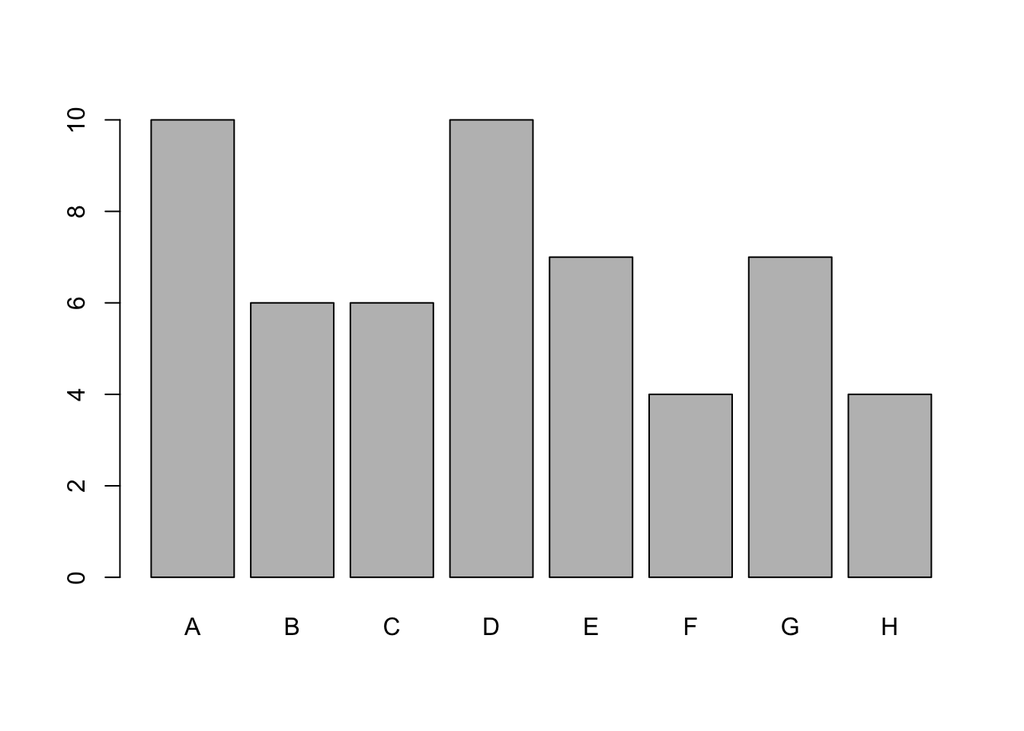

```r
#barplot(school) # this isn’t correct
barplot(table(school)) # Yes, call with summarized data
```

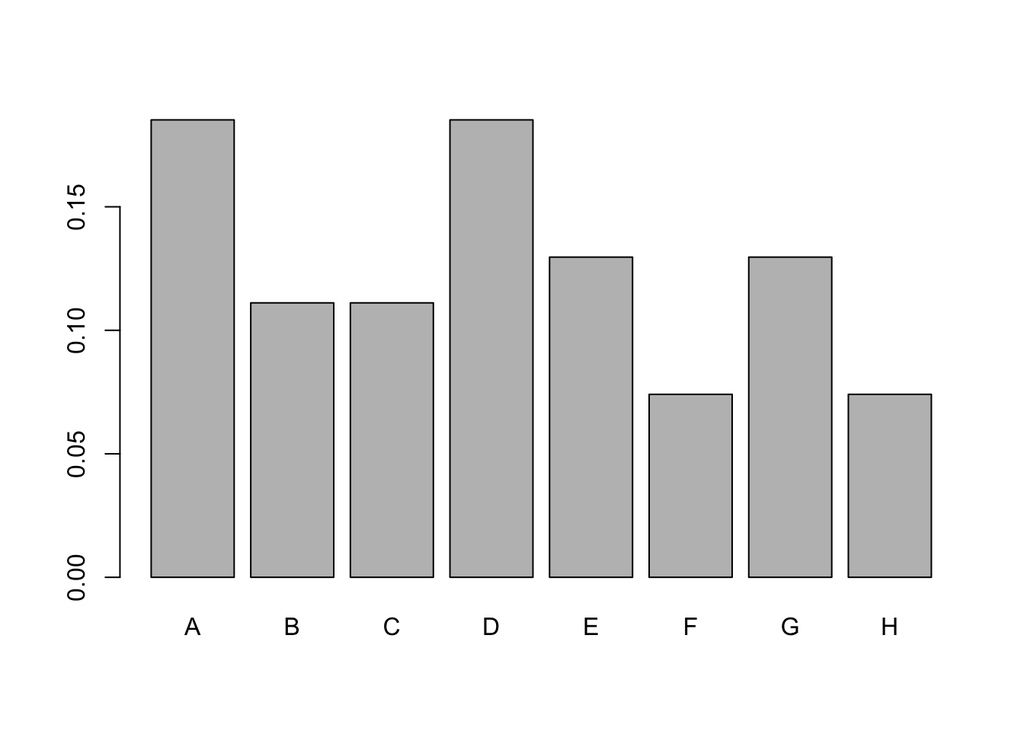

```r
barplot(table(school)/length(school)) # divide by n for proportion
```

## Piecharts

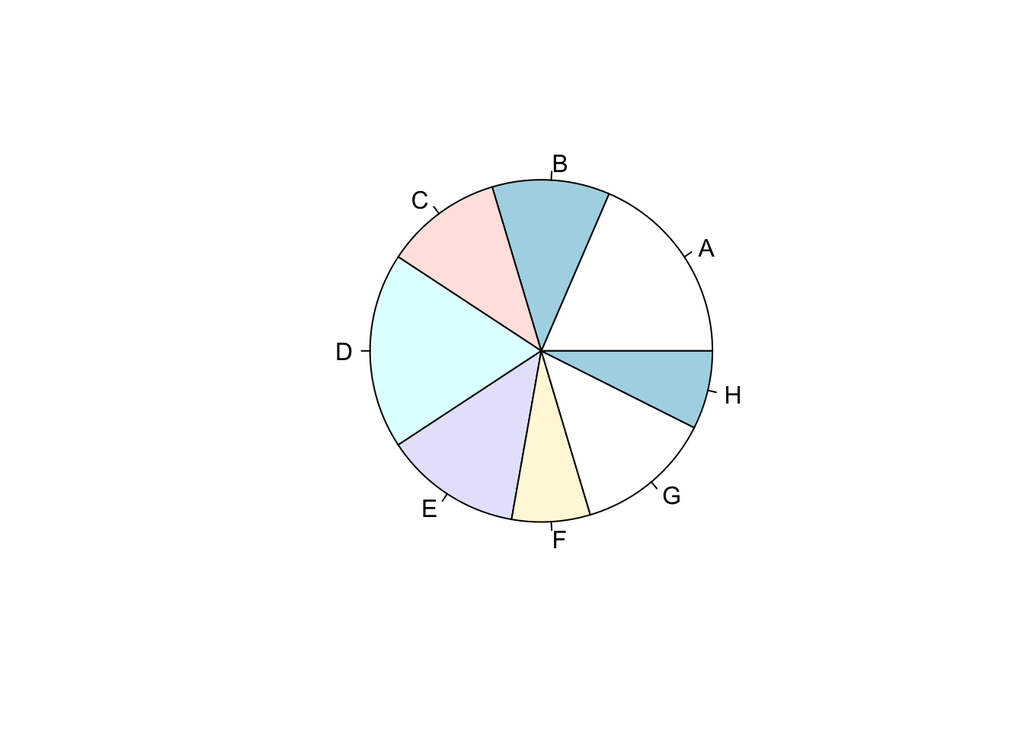

```r
school.counts = table(school) # store the table result
pie(school.counts) # first pie -- kind of dull
```

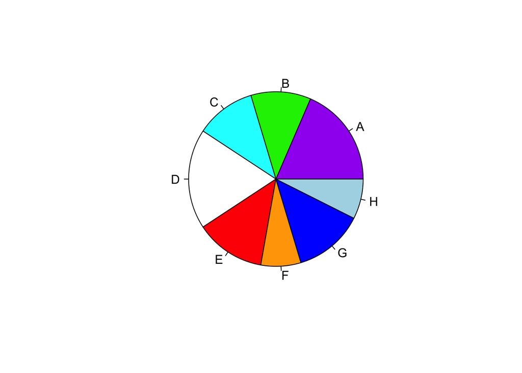

```r
#names(school.counts) = c("Italian","Tuscanian",...) # pie() prints out names
pie(school.counts,col=c("purple","green2","cyan","white","red","orange","blue","lightblue","black","grey")) # now with colors
```

# Numerical data

## Sorting

```r
sals = c(12, .4, 5, 2, 50, 8, 3, 1, 4, 0.25)
sort(sals)
```

```
##  [1]  0.25  0.40  1.00  2.00  3.00  4.00  5.00  8.00 12.00 50.00
```

## Mean, median, sd, vars, quantiles

```r
mean(sals)
```

```
## [1] 8.565
```

```r
var(sals)
```

```
## [1] 225.5145
```

```r
sd(sals)
```

```
## [1] 15.01714
```

```r
median(sals)
```

```
## [1] 3.5
```

```r
summary(sals)
```

```
##    Min. 1st Qu.  Median    Mean 3rd Qu.    Max.
##   0.250   1.250   3.500   8.565   7.250  50.000
```

## Histograms

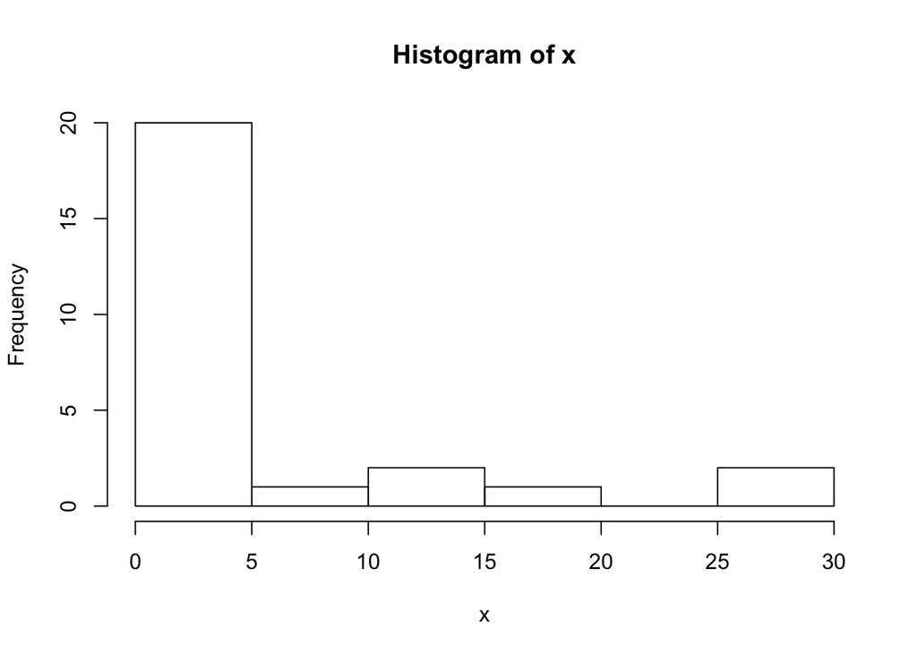

```r
x <- c(29.6, 28.2, 19.6, 13.7, 13.0, 7.8, 3.4, 2.0, 1.9, 1.0, 0.7, 0.4, 0.4, 0.3, 0.3, 0.3, 0.3, 0.3, 0.2, 0.2, 0.2, 0.1, 0.1, 0.1, 0.1, 0.1)
hist(x)     # frequencies
```

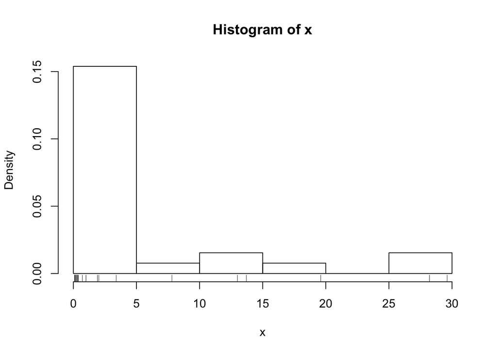

```r
hist(x,probability=TRUE) # proportions (or probabilities)
rug(jitter(x)) # add tick marks
```

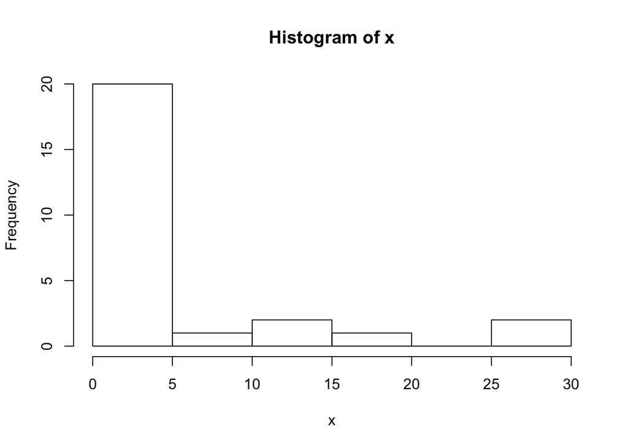

```r
hist(x,breaks=10) # 10 breaks, or just hist(x,10)
```

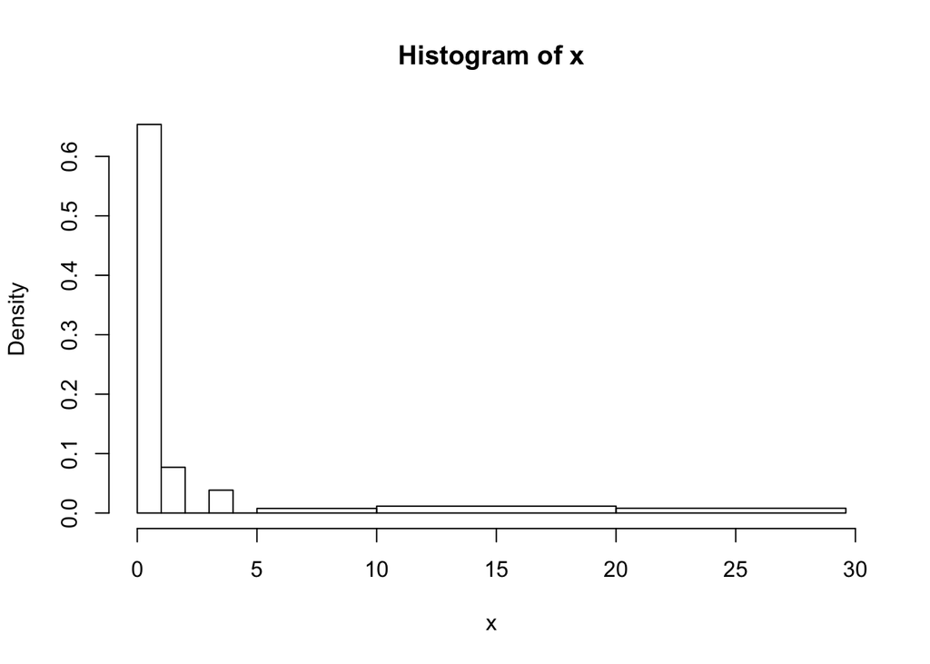

```r
hist(x,breaks=c(0,1,2,3,4,5,10,20,max(x))) # specify break points
```

## Boxplots

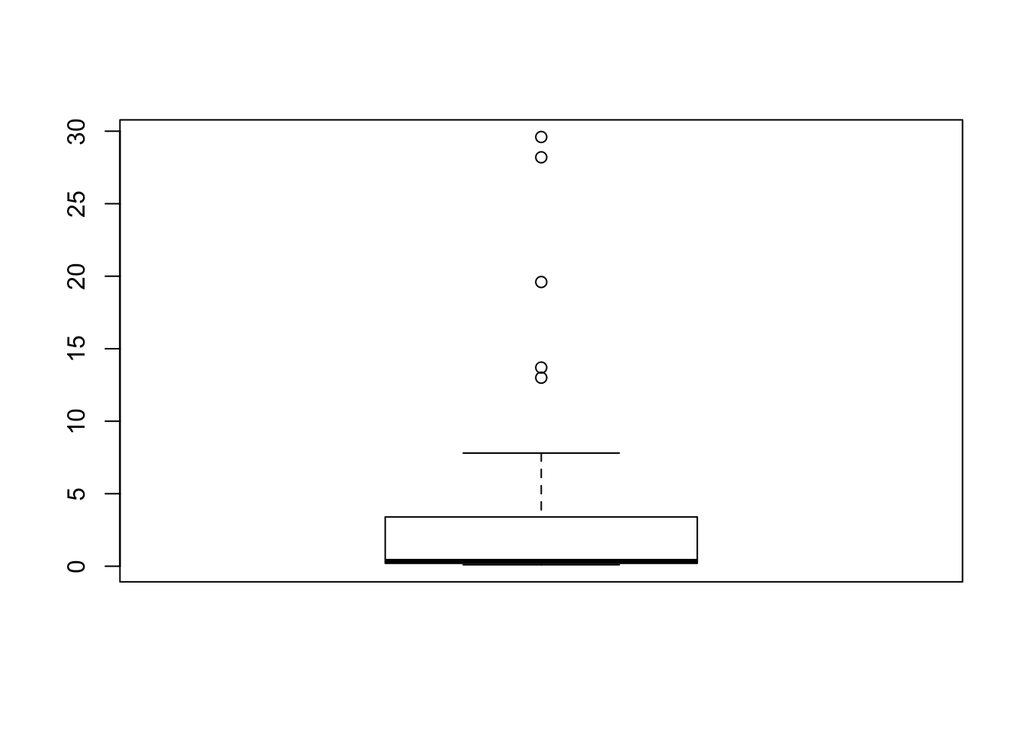

```r
boxplot(x)
```

## Frequency polygons

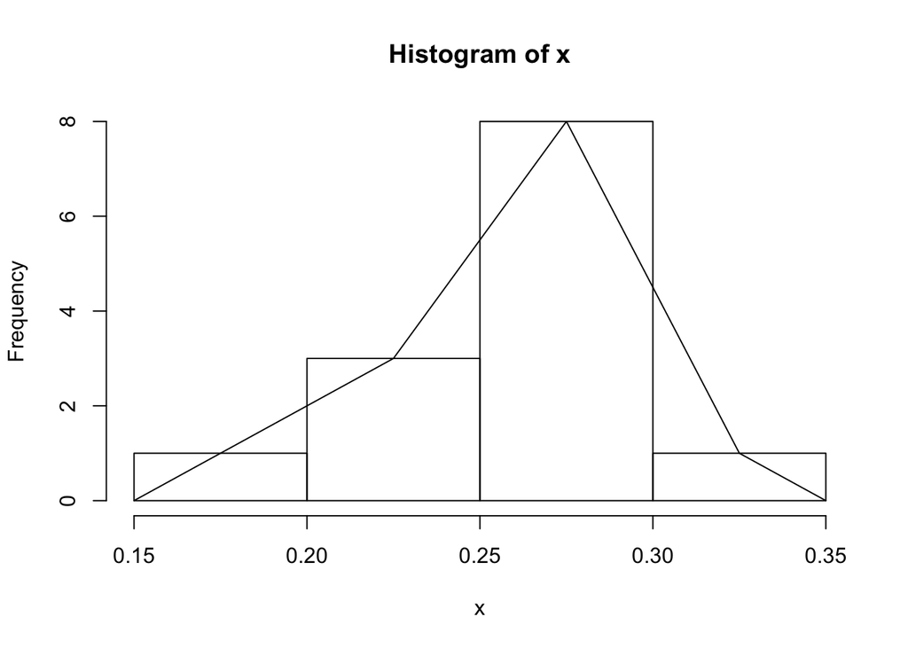

```r
x = c(.314,.289,.282,.279,.275,.267,.266,.265,.256,.250,.249,.211,.161)
tmp = hist(x) # store the results
lines(c(min(tmp$breaks),tmp$mids,max(tmp$breaks)),c(0,tmp$counts,0),type="l")
```

## Densities

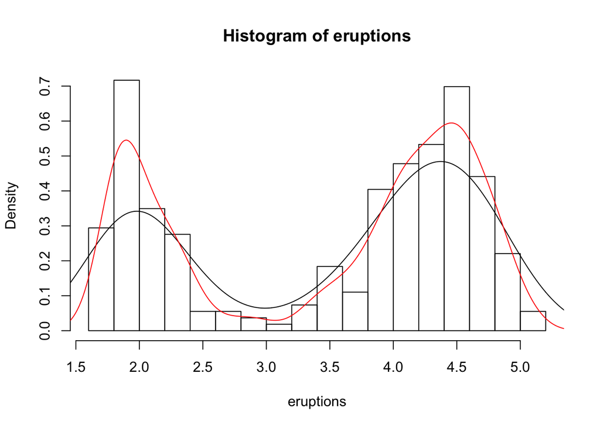

```r
data(faithful)
attach(faithful) # make eruptions visible
hist(eruptions,15,prob=T)  # proportions, not frequencies
lines(density(eruptions)) # lines makes a curve, default bandwidth
lines(density(eruptions,bw="SJ"),col="red") # Use SJ bandwidth, in red
```

# Bivariate data

## Categorical – categorical

```r
smokes = c("Y","N","N","Y","N","Y","Y","Y","N","Y")
amount = c(1,2,2,3,3,1,2,1,3,2)
table(smokes,amount)
```

```
##       amount
## smokes 1 2 3
##      N 0 2 2
##      Y 3 2 1
```

```r
tmp=table(smokes,amount) # store the table
old.digits = options("digits") # store the number of digits
options(digits=3)
prop.table(tmp,1)
```

```
##       amount
## smokes     1     2     3
##      N 0.000 0.500 0.500
##      Y 0.500 0.333 0.167
```

```r
prop.table(tmp,2)
```

```
##       amount
## smokes     1     2     3
##      N 0.000 0.500 0.667
##      Y 1.000 0.500 0.333
```

```r
amount
```

```
##  [1] 1 2 2 3 3 1 2 1 3 2
```

```r
# only print 3 decimal places #therowssumto1now
```

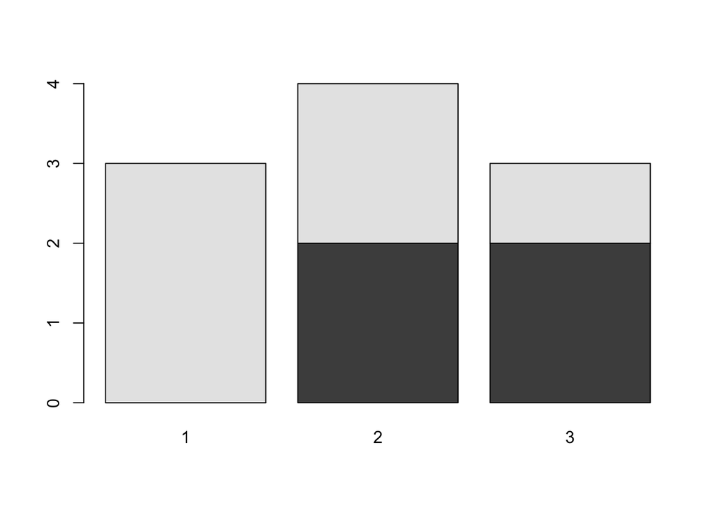

```r
barplot(table(smokes,amount))
```

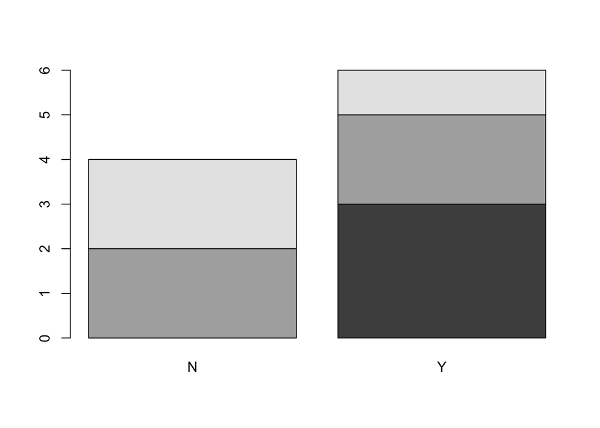

```r
barplot(table(amount,smokes))
```

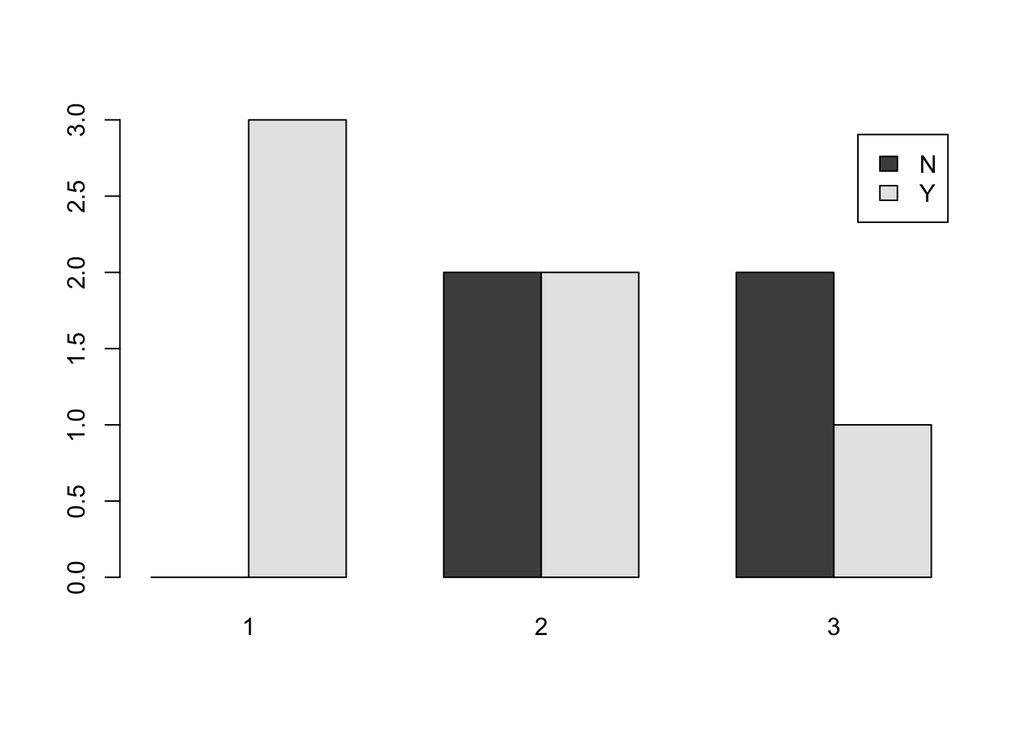

```r
smokes=factor(smokes) # for names
barplot(table(smokes,amount),
        beside=TRUE, # put beside not stacked
        legend.text=T) # add legend >
```

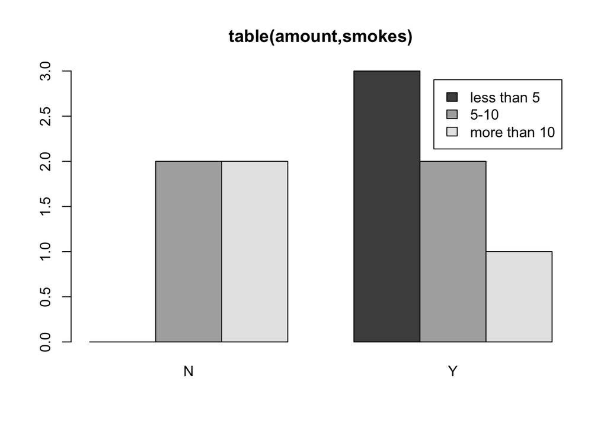

```r
barplot(table(amount,smokes),main="table(amount,smokes)",
        beside=TRUE,
        legend.text=c("less than 5","5-10","more than 10"))
```

## Numerical – categorical

Imagine you have measurements from same experiment with control group and test group. Plot them together to see how they look like with respect to each other.

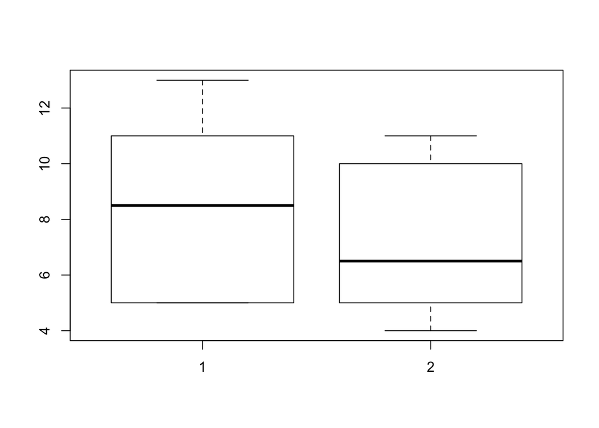

```r
x = c(5, 5, 5, 13, 7, 11, 11, 9, 8, 9)
y = c(11, 8, 4, 5, 9, 5, 10, 5, 4, 10)
boxplot(x,y)
```

Or you could also put it this way:

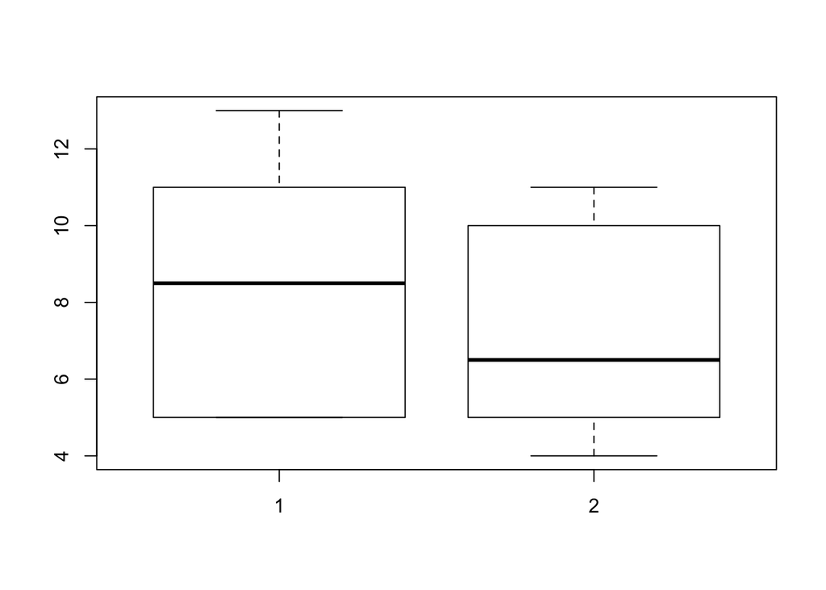

```r
amount <- c(5, 5, 5, 13, 7, 11, 11, 9, 8, 9, 11, 8, 4, 5, 9, 5, 10,5, 4, 10)
category <- c(1,1,1, 1,1, 1, 1,1,1,1, 2,2,2,2,2,2, 2,2,2, 2)
boxplot(amount ~ category) # note the tilde ~
```

## Numerical – numerical

### Compare two distributions with plots

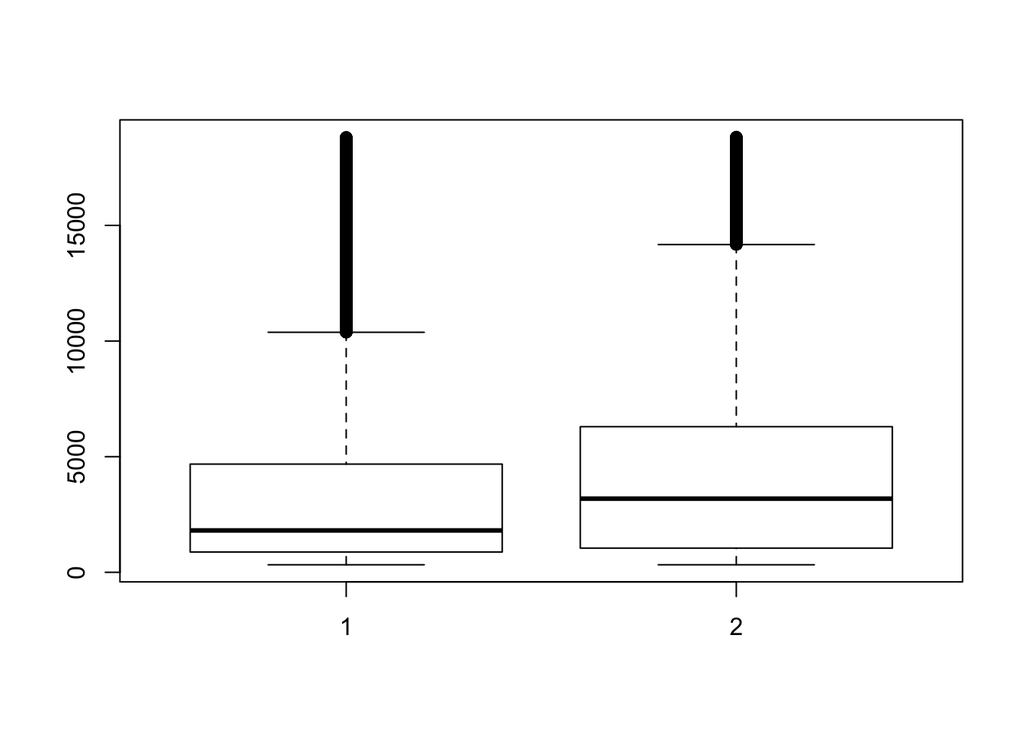

```r
library(ggplot2)
data(diamonds)
attach(diamonds)
ideal <- diamonds$price[diamonds$cut=="Ideal"]
premium <- diamonds$price[diamonds$cut=="Premium"]
boxplot(ideal,premium)
```

### Scatterplots

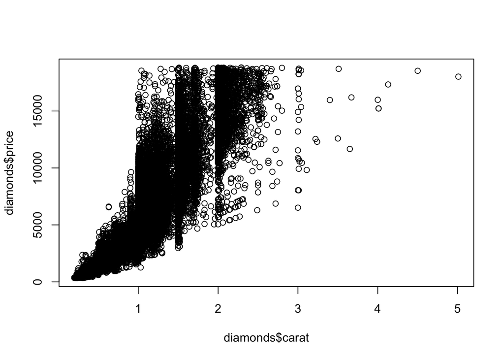

```r
plot(diamonds$carat,diamonds$price)
```

# Linear regression

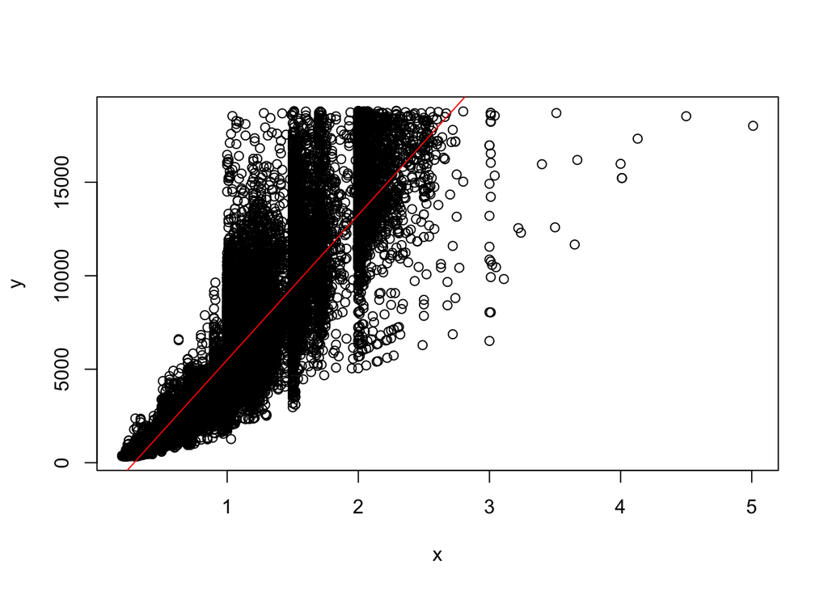

```r
y = diamonds$price
x = diamonds$carat
plot(x,y)
abline(lm(y ~ x), col="red")
```

```r
lm.res = lm(y~x) # store the answers in lm.res
coef(lm.res)
```

```
## (Intercept)           x
##       -2256        7756
```

```r
coef(lm.res)[1] # first one, use [2] for second
```

```
## (Intercept)
##       -2256
```

## Residuals

```r
summary(residuals(lm.res))
```

```
##    Min. 1st Qu.  Median    Mean 3rd Qu.    Max.
##  -18600    -805     -19       0     537   12700
```

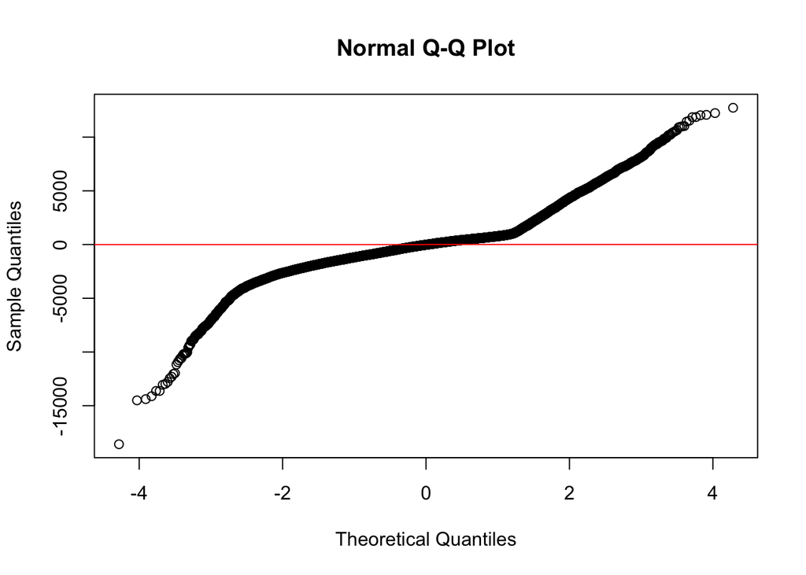

```r
qqnorm(residuals(lm.res))
abline(0,1,col="red")
```

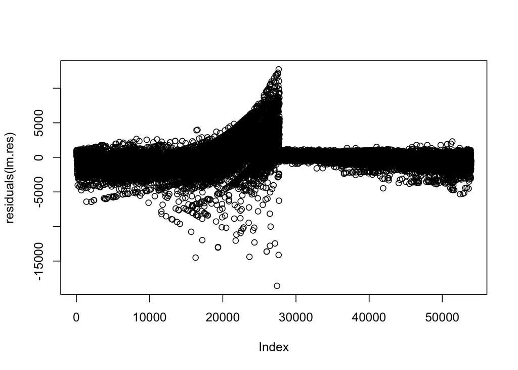

```r
plot(residuals(lm.res))
```

## Correlation

```r
cor(x,y) # to find R
```

```
## [1] 0.922
```

```r
cor(x,y)^2 # to find R^2
```

```
## [1] 0.849
```

# Tasks

**Exercise 1.** For the Simple data sets `bumpers`, `firstchi`, `math` make a histogram. Try to predict the mean, median and standard deviation. Check your guesses with the appropriate R commands.

**Exercise 2.** A student evaluation of a teacher is on a 1-5 Leichert scale. Suppose the answers to the first 3 questions are given in this table:

| Student | Ques. 1 | Ques. 2 | Ques. 3 |
| --- | --- | --- | --- |
| 1 | 3 | 5 | 1 |
| 2 | 3 | 2 | 3 |
| 3 | 3 | 5 | 1 |
| 4 | 4 | 5 | 1 |
| 5 | 3 | 2 | 1 |
| 6 | 4 | 2 | 3 |
| 7 | 3 | 5 | 1 |
| 8 | 4 | 5 | 1 |
| 9 | 3 | 4 | 1 |
| 10 | 4 | 2 | 1 |

Enter in the data for question 1 and 2.

```r
evaluation = data.frame(Student=1:10,Ques1=c(3,3,3,4,3,4,3,4,3,4),Ques2=c(5,2,5,5,2,2,5,5,4,2),Ques3=c(1,3,1,1,1,3,1,1,1,1))
```

1. Make a table of the results of question 1 and question 2 separately.
2. Make a contingency table of questions 1 and 2.
3. Make a stacked barplot of questions 2 and 3.
4. Make a side-by-side barplot of all 3 questions.

**Exercise 3.** The built-in data set `mtcars` contains information about cars from a 1974 Motor Trend issue. Load the data set (data(mtcars)) and try to answer the following:

1. What are the variable names? (Try `names`.)
2. what is the maximum mpg
3. Which car has this?
4. What are the first 5 cars listed?
5. What are all the values for the Mercedes 450slc (`Merc 450SLC`)?
6. Make a scatterplot of cylinders (`cyl`) vs. miles per gallon (`mpg`). Fit a regression line. Is this a good candidate for linear regression?

**Exercise 4.** You performed a genetic modification of bacteria. You wanted to estimate how this modification influenced its life span and measured the lengths of life for 25 bacteria. But your colleague told you that he already did this modification and length of life was equal to 80 minutes. Is your colleague right? Can you trust him or is he just trying to ruin your research?

```r
life_span <- c(88.1182719073621, 94.8332872750113, 93.216098240428, 94.4837517244522, 89.0162824741825, 98.3549941533524, 90.9306505649222, 79.4738128933811, 95.7943525794675, 79.907550971115, 67.5608620077608, 84.1118666207429, 80.4405426387418, 93.8668348621264, 77.2212434214561, 68.1068633480655, 84.8906327374611, 75.2442966398898, 92.1865794241239, 92.1903595428325, 83.4280593426128, 81.6008659108239, 74.223954191764, 106.223060058316, 91.3518150269478)
t.test(life_span, mu=80)
```

```
##
##  One Sample t-test
##
## data:  life_span
## t = 3, df = 20, p-value = 0.003
## alternative hypothesis: true mean is not equal to 80
## 95 percent confidence interval:
##  82.3 90.2
## sample estimates:
## mean of x
##      86.3
```

**Exercise 5**. You have group of samples who recieved new drug and group of sample that were cured according to the standard protocol. You were told that 20 patients with the disease were selected from the population and divided into 2 equal groups: 10 and 10. You measure hormone levels that are known to be distributed normally, and the lower level is the better. Is your new drug better?

```r
treated_group <- c(9830.76249436958, 6161.37243638468, 13131.8353604025, 10284.6598357407, 9245.98726622183, 7175.32445354559, 11174.4236746503, 12437.8577787669, 7093.47847958366, 9925.07623800654)
control_group <- c(12253.9047358527, 11425.4583361033, 11659.6962460054, 11759.4030595056, 9671.33755357213, 13352.9689425818, 7974.08085172749, 11220.3927754223, 12885.6045226814, 13032.8169883379)
t.test(treated_group, control_group,alternative="less")
```

```
##
##  Welch Two Sample t-test
##
## data:  treated_group and control_group
## t = -2, df = 20, p-value = 0.03
## alternative hypothesis: true difference in means is less than 0
## 95 percent confidence interval:
##  -Inf -318
## sample estimates:
## mean of x mean of y
##      9646     11524
```